[output not shown]

```r
# Seed for random number generation
set.seed(42)
knitr::opts_chunk$set(cache.extra = knitr::rand_seed)
pacman::p_load(grid,
               jpeg)
#out <- readRDS("../../data/pre_compile.rds")

out <- list()
out$n_sites_total   <- 52900
out$n_samples_total <- 180188
out$n_sites_li      <- 13228
out$n_sites_close   <- 32219

source("../parts/tab1.R")
```

# Introduction

Freshwater ecosystems provide humanity with clean drinking water and food, they ensure livelihoods for fisheries and farms, regulate our climate and they are places of high recreational and aesthetic value [@bene2016contribution; @borger2021value; @youn2014inland]. Lakes and rivers provide ecosystem services that are estimated to have a global annual worth of over 2.5 trillion dollars [2010US\$,@costanza2014changes], which corresponds approximately three percent of the global Gross Domestic Product as of 2017 [2010US\$, @WorldBank2021]. However, human activities have reduced biodiversity in freshwater ecosystems on a global scale [@Darwall2018; @almond2020living] and are thereby altering these systems’ capacities to provide ecosystem services [e.g. @cardinale2011biodiversity; @Duffy2017; @Grizzetti2019]. To prevent unacceptable harm to freshwater ecosystems and secure the supply of their services, internationally coordinated action and regulatory frameworks are necessary [@Darwall2018; @tickner2020bending; @van2021safeguarding].

The European Water Framework Directive [WFD, @EuropeanCommission2000] is among the major regulatory frameworks that aim to protect and restore freshwater systems in the European Union (EU). It aims to reach or maintain a *good ecological status* for most water bodies in the EU. Since its implementation in 2000, the WFD has motivated improvements in methods for biomonitoring [@Birk2012; @Carvalho2019], advanced our understanding of the ecological status of freshwater systems throughout Europe [@kristensen2018european] and has stimulated research at the science-policy interface [@reyjol2014assessing]. It has not, however, reached its explicit goal, to achieve *good ecological status* for most surface and groundwater bodies by 2015. As of 2018, 40% of surface water bodies had reached this status [@kristensen2018european]. The underlying status assessments differ between EU countries, as each uses a set of national methods [@Birk2012]. To harmonize them and to ensure a coherent notion of *good ecological status*, the EU initiated an intercalibration process. A recent output of this process are the *broad river types*, a pan-European typology of lotic freshwater systems [@LycheSolheim2019].

Most environmental regulatory frameworks summarize their focal ecosystems in typologies and the *broad river types* are not the first river typology to be used within the WFD. Each member state uses its own river typology and these national typologies vary widely in the number of river types they discern (between 1 and 367) and the variables that define them [@LycheSolheim2019]. In general, typologies are used to predict target properties at large spatial scales. Such properties can be nutrient and pollutant thresholds or the composition of ecological communities. To be of use, typologies do not need to suppose that these properties are constant within types - only that within-type variation is negligible compared to between-type variation.

There has been considerable disagreement at what spatial scale such typologies should operate. Possible scales range from microhabitat systems, like fine gravel patches, that merely span centimeters to ecoregions that can cover many hundred square kilometers [@frissell1986hierarchical]. The different spatial scales entail different geometries and topologies of the basic mapping units. The basic unit of a typology that is based on regions is a polygon and each type occurs usually only once. Most river reaches share their type with their in- and outflowing reaches as well as with all reaches in close proximity. Reaches with different types are only close at the borders between different regions. The basic spatial unit in a typology of river reaches is a line segment. Each type is assigned to many mapping units which are not necessarily contiguous. Instead, the landscapes are usually mosaics of different types in close proximity. Because typologies are models [@goodwin1999fluvial; @Loveland2004], there is not one correct answer. The optimal spatial scale and hence geometry depends on the purpose of the typology.

The *broad river types* are a reach-scale typology. @LycheSolheim2019 combined the more than 1000 national river types into 20 river types and connected them with the established intercalibration types [@Birk2013; @poikane2014intercalibration]. As some of the initial 20 types were rare or deemed redundant, an aggregated version with 12 types was proposed. The *broad river types* adopt the type descriptors that are most commonly used in national typologies: catchment size, altitude, geology, region and flow. The first three descriptors are part of the System A approach outlined in the Annex II of the WFD and @LycheSolheim2019 largely follow the class thresholds proposed there. While System A includes a region descriptor that recognizes 25 distinct regions throughout Europe, the region descriptor used by @LycheSolheim2019 only separates between the Mediterranean and the rest of Europe. Flow is also considered as a binary variable (perennial / intermittent) and was only applied to rivers in the Mediterranean region.

Despite the quick adoption of the *broad river types* in the research community [e.g. @birk2020impacts; @Poikane2019; @Posthuma2020], their biological validity remains to be established. In this context, a biologically valid typology is one, whose types delineate ecological communities that are more similar within than between types. Numerous studies have evaluated the biological validity of the national typologies [e.g. @Aroviita2008;@Lorenz2004;@Davy-Bowker2006;@sanchez2007concordance;@Chaves2011;@Lazaridou2013;@Zahradkova2005] that were the starting point for the *broad river types*. However, neither the failure nor the success of these national typologies would necessarily imply that their combination maintains this quality. The WFD uses four groups of organisms as so-called biological quality elements: macroinvertebrates, macrophytes, algae and fish. A river typology within the WFD should therefore try to summarize the variability in each of these groups [@Dodkins2005], however, in this study we will focus on macroinvertebrates.

A potential issue of the *broad river types* as a classification of European macroinvertebrate communities, pertains to the aforementioned topology of reach-scale typologies. Instances of a type can be thousands of kilometers apart (e.g. RT4 (Medium-large, siliceous and organic lowland rivers) occur in northern Norway and northern Portugal) while multiple different types are usually in close proximity. Such a classification of macroinvertebrate communities implicitly assumes that dispersal processes are overwhelmed by species sorting. Too much dispersal leads to mass effects and homogenization between adjacent reaches; too little dispersal and individuals can not reach potentially favorable river reaches, which increases the variance within types [e.g. @Tonkin2018].  
We propose to address this issue by combining the *broad river types* with a regional typology, effectively constraining the types spatially. To this end we will consider two pan-European region-based typologies: Illies Freshwater Ecoregions [IFE, @illies1978limnofauna] and the European Biogeographical Regions [BGR, @EuropeanEnvironmentalAgencyEEA2016].

In this paper, we aim to test whether the *broad river types* are biologically valid and to propose a possible improvement. To this end, we will first derive two new river typologies based on the combinations of IFE and BGR with the *broad river types*.  
We will then evaluate the five typologies (*broad river types*, IFE, BGR, and the two combinations) by analyzing the within and between type similarities of macroinvertebrate communities and determining whether we can derive distinct typical communities for the types.  
With these analyses we will test three hypotheses:  
H1: Macroinvertebrate communities are more similar within than between *broad river types*.  
H2: The *broad river types* are a better classification of macroinvertebrate communities than either IFE or BGR.  
H3: Combining the *broad river types* with BGR or IFE provides better classifications than the *broad river types*.

# Methods

## Preparation of macroinvertebrate data

```r
#knitr::include_graphics("../../fig/2021-09-23_map.png")
```

We used the Global Biodiversity Information Facility (www.gbif.org) to replace synonyms with accepted names and to assign a taxonomic level to each observation. We restricted observations to the classes Insecta, Gastropoda, Bivalvia, Malacostraca, and Arachnida. Within these classes we further reduced the data to the orders: Trombidiformes, Megaloptera, Isopoda, Littorinimorpha, Odonata, Sphaeriida, Hemiptera, Amphipoda, Coleoptera, Trichoptera, Diptera, Ephemeroptera and Plecoptera. Taxa without currently accepted orders (e.g. Pulmonata) were also included.

## Selection of sampling sites

Repeated samples from the same site in the same season are often very similar [@lorenz2006sample]. To avoid this factor from artificially increasing the within type similarity we aggregated such samples. Aggregated sites included all taxa that occurred in at least 50% of samples taken at the site within the respective season.

```r
#knitr::kable(tab1, caption = "Placeholder")
caption.text <-
"Overview of individual data sets. Number of samples and sites refers to the least impacted sites within 500 meters of a river reach in the digital representation of the broad river types. pHMS stands for proportional multihabitat sampling. To avoid unnecessary repetition we summarized the following sampling schemes by their names:
AQEM (pMHS with kicknet; 20 sampling units; 25cm x 25cm frame, 500 μm mesh size), PERLA (pMHS with kicknet; 3 minutes; 25cm x 35 cm frame and 500 μm mesh size);  AFNOR XP T 90 333 (pMHS with kicknet; 12 samples, 20cm x 25cm; 500 μm mesh size)."

tab1 |>
        papaja::apa_table(digits = 0,
                          longtable = TRUE,
                  caption = caption.text)
```

(#tab:datasets)

*Overview of individual data sets. Number of samples and sites refers to the least impacted sites within 500 meters of a river reach in the digital representation of the broad river types. pHMS stands for proportional multihabitat sampling. To avoid unnecessary repetition we summarized the following sampling schemes by their names: AQEM (pMHS with kicknet; 20 sampling units; 25cm x 25cm frame, 500 µm mesh size), PERLA (pMHS with kicknet; 3 minutes; 25cm x 35 cm frame and 500 µm mesh size); AFNOR XP T 90 333 (pMHS with kicknet; 12 samples, 20cm x 25cm; 500 µm mesh size).*

| ID | name | sites (samples) | sampling method |
| --- | --- | --- | --- |
| 1 | Project AQEM (Romania) | 12 (79) | AQEM |
| 2 | Project AQEM (Sweden) | 33 (66) | AQEM |
| 3 | Project Biodrought | 2 (4) | PERLA |
| 4 | Cantabria and Picos de Europa | 39 (39) | AQEM |
| 5 | Ebro Hydrographic Confederation | 254 (463) | AQEM |
| 6 | Project Ecosurv | 71 (71) | AQEM |
| 7 | Koutajoki Basin | 3 (3) | pMHS with kicknet; 4 samples, 30s each; 300 Î¼M mesh size |
| 8 | Naiades | 1345 (2304) | AFNOR XP T 90 333 |
| 9 | Monitoring Czech Republic (Salamander) | 1 (1) | PERLA |
| 10 | Project STAR | 11 (11) | AQEM |
| 11 | Monitoring France (RCS Network) | 975 (975) | AFNOR XP T 90 333 |
| 12 | Monitoring Germany | 2005 (3122) | AQEM |
| 13 | Monitoring Greece | 36 (36) | pHMS with kicknet; 3 minutes; 25cm x 23cm frame; 900 Î¼M mesh size |
| 14 | Monitoring Netherlands | 32 (56) | pHMS with handnet; 5 meters; 30cm x 15 cm frame; 500 Î¼M mesh size |
| 15 | Monitoring Poland | 746 (887) | AQEM |
| 16 | Monitoring Portugal | 249 (257) | pMHS with kicknet; 6 Samples; 25cm x 25cm frame; 500 Î¼M mesh size |
| 17 | Monitoring Romania | 4 (10) | AQEM |
| 18 | Monitoring Slovakia | 9 (9) | AQEM |
| 19 | Monitoring Spain | 1062 (1411) | AQEM |
| 20 | Monitoring Czech Republic | 299 (636) | PERLA |
| 21 | Segura Basin | 24 (24) | pMHS with kicknet; 500 Î¼M mesh size |
| 22 | Project WISER | 202 (202) | AQEM |
| 23 | Monitoring UK | 559 (1096) | pHMS with kicknet; 3 minutes; 1000 Î¼M mesh size |
| 24 | Monitoring Belgium | 5 (9) | pHMS with kicknet; 3-5 minutes; 300-500 Î¼M mesh size |
| 25 | Monitoring Finland | 264 (264) | pMHS with kicknet; 4 samples, 30s each; 300 Î¼M mesh size |
| 26 | Monitoring Croatia | 0 (0) | missing |

## Adding regions to the broad river types

We established two new pan-European typologies by combining the *broad river types* with BGR and IFE. In the following, we will refer to these two new typologies as $BRT_{BGR}$ and $BRT_{IFE}$. First, we intersected the digital representation of the *broad river types* [@globevnik2019btfr] with IFE and BGR. This resulted in a $BRT_{BGR}$ with 130 types and a $BRT_{IFE}$ with 245 types. To simplify the new typologies we combined rare (<200 reaches in total or <5% of reaches within region) river types with similar types (see SI). For very large rivers (RT1 in the *broad river types*) we used the types proposed by @borgwardt2019ex. The simplified typologies consist of 63 ($BRT_{BGR}$) and 114 ($BRT_{IFE}$) types.

## Evaluation of typologies

To test our three hypotheses, we evaluated the classification performance of each typology using four approaches. First, Analysis of similarity [ANOSIM, @clarke1993non] is a non-parametric multivariate method, testing the null hypothesis that the average rank of within-group similarities is smaller than or equal to the average ranks of between-group similarities. It does so using the following formula:
$$R = \frac{\bar{r}_B - \bar{r}_W}{(N(N-1)/2)/2}$$
where $\bar{r}_B$ is the mean rank of similarities between groups, $\bar{r}_W$ within groups and $N$ is the number of samples. The denominator standardizes the $R$ statistic to range between -1 and 1. $R$ is 1 if all samples within a type are more similar to another than to samples from other types and zero if the tested null hypothesis is true.
An $R$ statistic above 0.75 indicates clear separation between groups, R between 0.75 and 0.5 weaker separation with overlapping groups and R above 0.25 weak separation [@clark2001primer]. Besides these heuristics, a pseudo-*p*-value based on 999 permutations of cluster identity is computed. We computed ANOSIMs with the vegan R package [@Oksanen2020].

Second, the classification strength (CS) of a classification is the difference between the mean within cluster similarity ($\bar{W}$) and the mean between cluster similarity ($\bar{B}$), i.e.
$$CS = \bar{W} - \bar{B}$$
[@VanSickle1997]. It ranges between 0 ($\bar{B} = \bar{W}$) and 1 ($\bar{B} = 0$ and $\bar{W} = 1$). To account for unequal cluster sizes, a weighted mean is used to compute $\bar{W}$, i.e. $\bar{W} = \Sigma_i\frac{n_i}{N}W_i$ with $n_i$ the number of sites in cluster $i$ and N the total number of sites. As with ANOSIM a pseudo-*p*-value is computed by permuting the type membership of samples 999 times. The CS was computed with a purpose-written R-function that is available as supplementary information. Both approaches have previously been used to evaluate national stream typologies [e.g. @sandin2000ecoregions;@sanchez2007concordance]. We expected their results to be qualitatively similar but computing both allowed us to compare the effectiveness of these pan-European typologies to smaller scale typologies that were evaluated with these metrics.

Third, we derived indicator taxa for each type of each typology using the Indicator Value (IndVal) approach of @dufrene1997species. The IndVal is the product of the two quantities $A$ and $F$ (commonly denoted $B$ but renamed here to prevent confusion with between-cluster similarity). $A$ is the relative number of observations of taxon $i$ that are within type $j$. It was initially described as specificity but is better understood as concentration [@Podani2010] because it is independent of the total number of types. $F$ is the relative frequency with which species $i$ occurs in type $j$. The maximum score is assigned to a species that only occurs in one type ($A$ = 1) and occurs in all samples of that type ($F$ = 1). Here, we used the group-equalized version of the IndVal which accounts for the fact that the number of samples differs between types. The statistical significance of the IndVal statistic was assessed with a permutation test that computed IndVal values for random permutations of type membership and compared the observed IndVal against this empirical distribution. We used 999 permutations and used the number of statistically significant indicator taxa (*p*<0.05) as test statistic.

The number of indicator taxa is a lenient criterion as the IndVal explicitly includes the concentration $A$. A stricter test, could omit $A$ and only focus on the relative frequency of occurrence $F$. Here, we derived common communities for each type, which consisted of all families with $F>0.66$. The mean Jaccard similarity between common communities of a typology was used as test statistic and a pseudo-*p*-value derived by permuting the type membership among sites 999 times.

## Data and Software

Illies freshwater ecoregions were queried from https://www.eea.europa.eu/data-and-maps/data/ecoregions-for-rivers-and-lakes and the EEA biogeographical regions from https://www.eea.europa.eu/data-and-maps/data/biogeographical-regions-europe-3 (both Accessed 08.01.2020). All computations were conducted in the R Statistical Environment v. 4.0.3 [@RCT2020]. Data were prepared using data.table 1.14.0 [@Dowle2021], tidyverse packages [@Wickham2019] and taxize 0.9.98 [@ScottChamberlain2013; @Chamberlain2020]. Geospatial analyses were conducted using sf [@Pebesma2018]. Clusters were created and evaluated with fpc [@Hennig2020] and indicspecies [@caceres2009associations]. Generalized silhouette widths were computed with the R functions provided in the supplementary information of @Lengyel2019. Figures and maps were created with ggplot2 [@Wickham2016] and tmap [@Tennekes2018].

# Results

## Classification strength

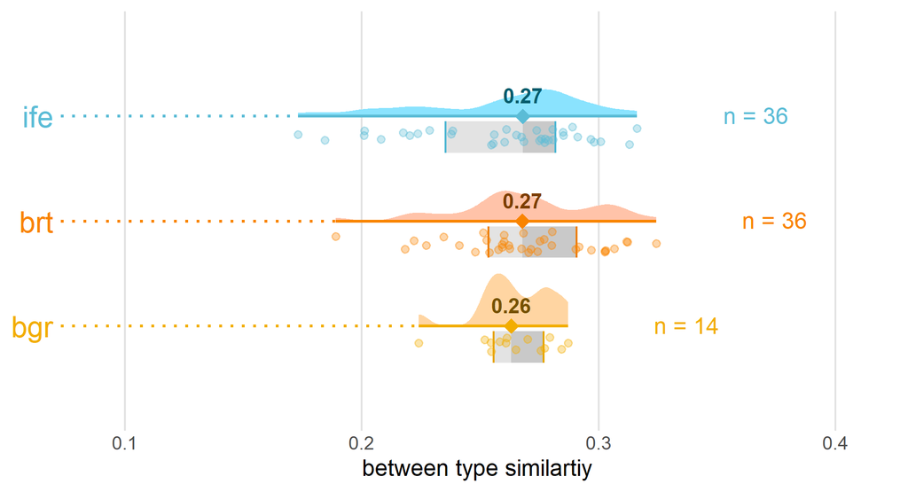

```r
knitr::include_graphics("../../fig/results_classification_strength/2021-10-18_between_similartiy.png")
```

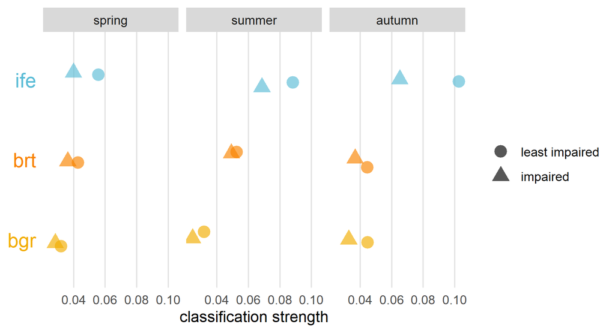

```r
knitr::include_graphics("../../fig/results_classification_strength/2021-10-18_classification_strength.png")
```

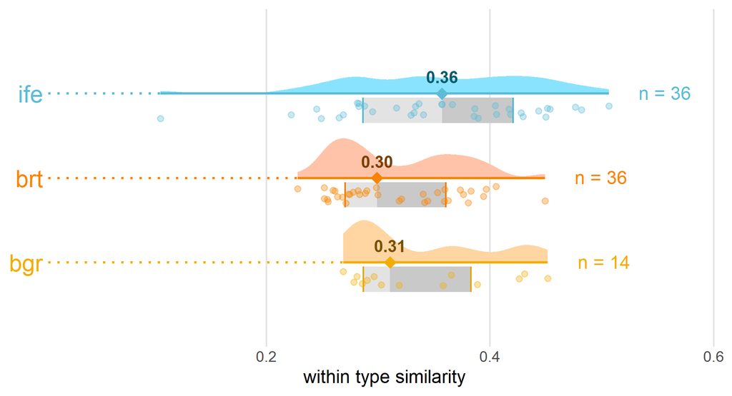

```r
knitr::include_graphics("../../fig/results_classification_strength/2021-10-18_within_similartiy.png")
```

# Discussion

R values > 0.75 are commonly interpreted as well separated, R > 0.5 as separated, but overlapping, and R > 0.25 as barely separable (Clarke & Gorley, 2001).

# Acknowledgements

thanks for pointing to data Agnez Bouchez, Stéphanie Couprie, Lucie Clavel Geoff Phillips, John Murray-Bligh